# **Activity vignette**

Pablo Palencia

2022-11-04

# 1. Background

Getting activity patterns is one of the most habitual analyses of camera trap data. It is visual, intuitive and interesting. In addition, activity level (i.e. the proportion of the day that the population spend in movement), is a basic parameter for lastly estimate other ecological parameters. Here, I provide a simple example to estimate activity pattern and activity level (and their precision). Now there are no reasons to just plot the raw data and include it in your thesis, reports, etc!

# 2. Let’s do it!

## 2.1 Load data and *activity* package

We will use the *activity* package.

```r
# Load data frame
data_activity <- read.table("Data.txt", sep = ";", dec=".", header=TRUE, as.is=TRUE) # data frame

# Data frame structure:
# N_ind: Number of individuals recorded
# Time: Time (HH:MM:SS format) when animals were recorded

#install.packages("activity") # just in case you didnt install the package previously
library(activity) # load package
```

## 2.2 Preparing the data

Two main steps:

First, we will replicate those sequences in which more than one individual were recorded. Take in mind that the basic data to estimate activity is the number of individuals active at a given time of the day. In our database, we included a row for each independent group of individuals. Now, we will duplicate rows till create a row for each individual (we will do it automatically, no worries!)

Second, we will transform clock time into radian (circular) units. (Note that 23:59 and 00:01 are far away on clock time, but actually only 2 minutes apart. Radian units solve this aspect). Again, we will do it in one line of code.

Please, see a more in detail explanation about activity and camera traps (method, assumptions…) in Rowcliffe et al. (2014) Methods Ecol. Evol. 5(11):1170-1179.

```r
# Replicating each sequence based on the number of animals recorded
data_activity.r <- data_activity[rep(row.names(data_activity), data_activity$N_ind), 1:2]

# Convert time of data to a numeric vector of radian time-of-day
data_activity.r$radtime <- gettime(data_activity.r$Time, "%H:%M:%S", "proportion")
radtime <- 2*pi*gettime(data_activity.r$Time, "%H:%M:%S", "proportion")
```

## 2.3 Fitting the model

Now we are going to fit the model using *fitact* function

```r
# fit activity model
actmod <- fitact(radtime, sample="data")
```

## 2.4 Exploring the results!

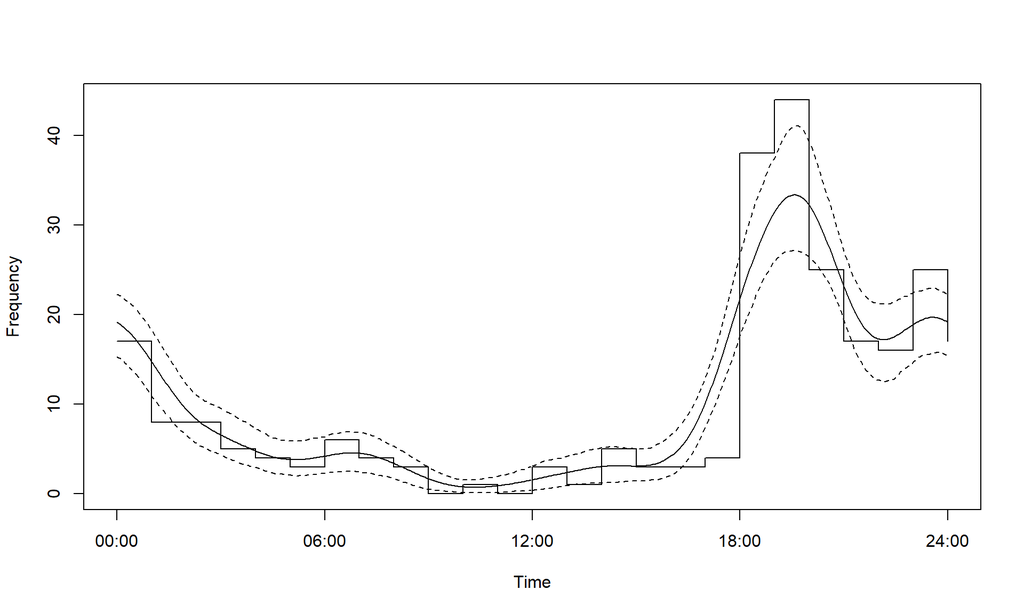

**Figure 1**: Activity pattern

```r
# plot activity pattern
plot(actmod)
```

```r
# activity level
actmod@act
```

```
##        act         se   lcl.2.5%  ucl.97.5%
## 0.30345156 0.03151874 0.24639860 0.37066810
```

Activity pattern: the plot showed a peak in activity pattern at the sunset (i.e. all the individuals in the population are active at this moment). During the night, the animals’ activity progressively decreases (i.e. resting period). The basal-diurnal activity is minimum. At this point I should clarify that the data come from a red deer (*Cervus elaphus*) population in central Spain sampled during spring.

Now you can run the code with your data and include the activity pattern, discuss the activity level, etc! Much more fancy!